# Exercícios - Regressão Linear Múltipla em R

23-10-2025

## Pacotes e dados

```r
# Instalar se necessário:
req <- c("tidyverse","broom","palmerpenguins","nycflights13","car","performance","GGally", "see")
new <- setdiff(req, rownames(installed.packages()))
if(length(new)) install.packages(new)

library(tidyverse)
library(broom)
library(palmerpenguins)
library(nycflights13)
library(car)           # VIF e diagnóstico
library(performance)   # checks de suposições
library(GGally)        # ggpairs
library(see)          # diagnóstico
```

## Conjunto de dados A: `penguins`

Descrição curta: pinguins de 3 espécies na Antártida, com medidas morfológicas e sexo.

```r
penguins <- palmerpenguins::penguins |> drop_na()
glimpse(penguins)
```

```
## Rows: 333
## Columns: 8
## $ species           <fct> Adelie, Adelie, Adelie, Adelie, Adelie, Adelie, Adel…
## $ island            <fct> Torgersen, Torgersen, Torgersen, Torgersen, Torgerse…
## $ bill_length_mm    <dbl> 39.1, 39.5, 40.3, 36.7, 39.3, 38.9, 39.2, 41.1, 38.6…
## $ bill_depth_mm     <dbl> 18.7, 17.4, 18.0, 19.3, 20.6, 17.8, 19.6, 17.6, 21.2…
## $ flipper_length_mm <int> 181, 186, 195, 193, 190, 181, 195, 182, 191, 198, 18…
## $ body_mass_g       <int> 3750, 3800, 3250, 3450, 3650, 3625, 4675, 3200, 3800…
## $ sex               <fct> male, female, female, female, male, female, male, fe…
## $ year              <int> 2007, 2007, 2007, 2007, 2007, 2007, 2007, 2007, 2007…
```

```r
summary(penguins)
```

```
##       species          island    bill_length_mm  bill_depth_mm
##  Adelie   :146   Biscoe   :163   Min.   :32.10   Min.   :13.10
##  Chinstrap: 68   Dream    :123   1st Qu.:39.50   1st Qu.:15.60
##  Gentoo   :119   Torgersen: 47   Median :44.50   Median :17.30
##                                  Mean   :43.99   Mean   :17.16
##                                  3rd Qu.:48.60   3rd Qu.:18.70
##                                  Max.   :59.60   Max.   :21.50
##  flipper_length_mm  body_mass_g       sex           year
##  Min.   :172       Min.   :2700   female:165   Min.   :2007
##  1st Qu.:190       1st Qu.:3550   male  :168   1st Qu.:2007
##  Median :197       Median :4050                Median :2008
##  Mean   :201       Mean   :4207                Mean   :2008
##  3rd Qu.:213       3rd Qu.:4775                3rd Qu.:2009
##  Max.   :231       Max.   :6300                Max.   :2009
```

## Conjunto de dados B: `nycflights13::flights`

Descrição curta: todos os voos a partir de NYC em 2013. Para tornar leve, usaremos uma amostra filtrada.

```r
flts <- nycflights13::flights |>
  filter(!is.na(dep_delay), !is.na(arr_delay),
         !is.na(distance), !is.na(air_time)) |>
  # amostra reprodutível
  slice_sample(n = 30000, replace = FALSE)
glimpse(flts)
```

```
## Rows: 30,000
## Columns: 19
## $ year           <int> 2013, 2013, 2013, 2013, 2013, 2013, 2013, 2013, 2013, 2…
## $ month          <int> 5, 3, 7, 1, 1, 8, 3, 4, 12, 10, 7, 8, 9, 12, 10, 11, 3,…
## $ day            <int> 9, 27, 30, 13, 24, 23, 1, 16, 28, 14, 28, 12, 28, 13, 9…
## $ dep_time       <int> 619, 1355, 1648, 2311, 607, 1557, 1431, 555, 853, 2006,…
## $ sched_dep_time <int> 624, 1400, 1630, 2005, 615, 1543, 1430, 600, 900, 2012,…
## $ dep_delay      <dbl> -5, -5, 18, 186, -8, 14, 1, -5, -7, -6, 247, -3, -8, -9…
## $ arr_time       <int> 805, 1453, 1922, 125, 752, 1843, 1710, 754, 1216, 2148,…
## $ sched_arr_time <int> 827, 1503, 1930, 2230, 750, 1845, 1732, 805, 1220, 2150…
## $ arr_delay      <dbl> -22, -10, -8, 175, 2, -2, -22, -11, -4, -2, 220, -23, -…
## $ carrier        <chr> "EV", "US", "AA", "9E", "MQ", "UA", "UA", "EV", "AA", "…
## $ flight         <int> 4471, 2130, 881, 4033, 4518, 1151, 1744, 5363, 2335, 41…
## $ tailnum        <chr> "N13979", "N946UW", "N3FKAA", "N8659B", "N722MQ", "N284…
## $ origin         <chr> "EWR", "LGA", "JFK", "LGA", "LGA", "EWR", "LGA", "LGA",…
## $ dest           <chr> "CLT", "BOS", "DFW", "TYS", "RDU", "SEA", "IAH", "MEM",…
## $ air_time       <dbl> 79, 38, 192, 105, 76, 323, 197, 143, 155, 71, 319, 50, …
## $ distance       <dbl> 529, 184, 1391, 647, 431, 2402, 1416, 963, 1096, 445, 2…
## $ hour           <dbl> 6, 14, 16, 20, 6, 15, 14, 6, 9, 20, 19, 18, 13, 7, 17, …
## $ minute         <dbl> 24, 0, 30, 5, 15, 43, 30, 0, 0, 12, 35, 25, 48, 10, 5, …
## $ time_hour      <dttm> 2013-05-09 06:00:00, 2013-03-27 14:00:00, 2013-07-30 1…
```

# Exercício 1 — Exploração inicial (EDA)

**1.1 (Penguins)** (a) Faça um *pair plot* das variáveis contínuas `bill_length_mm`, `bill_depth_mm`, `flipper_length_mm`, `body_mass_g` usando a função ggpairs do package GGally. (b) Calcule a matriz de correlações (com coeficiente de Pearson). (c) Comente potenciais colinearidades e relações com a resposta `body_mass_g`.

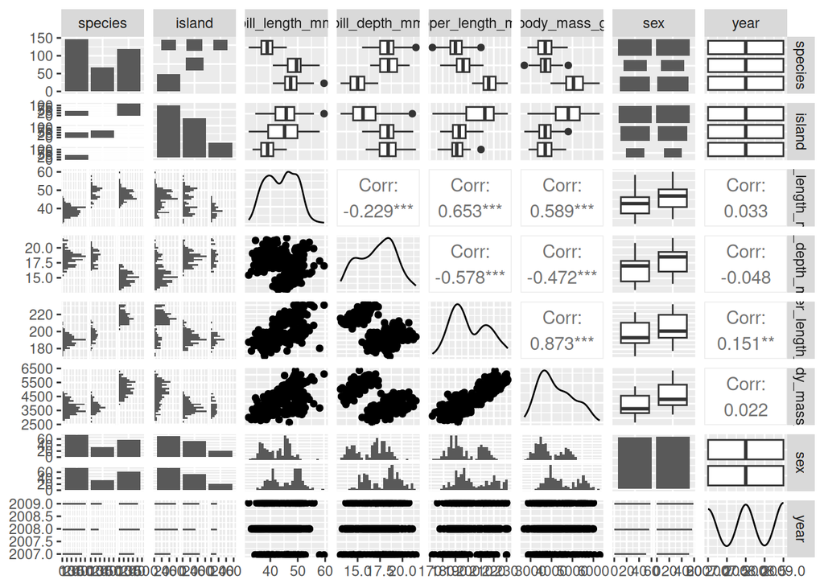

```r
tux<-penguins |>
  select(bill_length_mm, bill_depth_mm, flipper_length_mm, body_mass_g)

ggpairs(penguins)
```

**1.2 (Flights)** (a) Faça um *pair plot* de `arr_delay` (resposta), `dep_delay`, `distance`, `air_time`. (b) Calcule correlações e comente.

# Exercício 2 — Modelo base (Penguins)

**Objetivo:** modelar `body_mass_g` a partir de medidas do bico e da barbatana, controlando por espécie e sexo.

2.1. Ajuste o modelo:
$$\texttt{body_mass_g} \sim \texttt{bill_length_mm} +
\texttt{bill_depth_mm} * \texttt{flipper_length_mm} + \texttt{species} +
\texttt{sex}.$$

2.2. Interprete os coeficientes das variáveis contínuas (incluindo unidades) e o efeito marginal de `species` e `sex` (comparação com a categoria de referência).

2.3. Calcule os **VIFs** e comente a multicolinearidade.

# Exercício 3 — Diagnóstico do modelo (Penguins)

3.1. Faça gráficos padrão de diagnóstico e comente: linearidade, homoscedasticidade, normalidade dos resíduos, pontos influentes. Depois experimente usar a função check_model do package performance.

3.2. Se necessário, proponha **transformações** (por ex., `log(body_mass_g)` ou padronizar os preditores). Ajuste o modelo transformado e compare AIC, BIC e R² ajustado.

# Exercício 4 — Interações (Penguins)

4.1. Teste se o efeito de `flipper_length_mm` **varia por espécie**: inclua a interação `flipper_length_mm:species`.

Interprete um coeficiente de interação: o que significa para o declive entre `flipper_length_mm` e `body_mass_g` em, por exemplo, `species = Gentoo`?

4.2 — Efeito parcial de `flipper_length_mm` mantendo as outras variáveis constantes (com *ribbon*)

**Tarefa:** Trace a curva de predição média de `body_mass_g` em função de `flipper_length_mm`, **mantendo constantes** `bill_length_mm`, `bill_depth_mm`, `sex` e `species`. Use **intervalos de confiança de 95%** com `geom_ribbon()`.

> Dica: fixe as covariáveis nos seus valores medianos e varie `flipper_length_mm` numa grelha regular.

# Exercício 5 — Seleção de variáveis e validação

**5.1.** Em `penguins`, compare os modelos `m1` (base) e `m2` (com interação) usando AIC e (R^2) ajustado. Qual prefere e porquê?

## Exercício 6 — Predição pontual e intervalos (Penguins)

**6.1.** Usando o modelo selecionado para `penguins` (por ex., `m2`), faça **predições pontuais** e **intervalos de confiança** para a **média** e **intervalos de predição** para uma **nova observação** com:

- `bill_length_mm = 45`, `bill_depth_mm = 18`, `flipper_length_mm = 200`,
- `species = "Adelie"`, `sex = "male"`.

Compare numericamente **IC (mean)** vs **IP (pred)**.

# Exercício 7 — Modelo para atrasos de voo (Flights)

**Objetivo:** modelar `arr_delay` a partir de `dep_delay`, `distance`, `air_time` e efeitos *dummies* de companhia (`carrier`).

7.1. Ajuste o modelo:
$$\texttt{arr_delay} \sim \texttt{dep_delay} + \log(\texttt{distance}) +
\texttt{air_time} + \texttt{carrier}.$$

7.2. Discuta a interpretação do coeficiente de `dep_delay`. Explique por que `log(distance)` pode ser preferível a `distance`.

7.3. Verifique **heteroscedasticidade**.

7.4. Avalie **multicolinearidade** (VIF) e **pontos influentes** (Cook’s distance).

# Exercício 8 — Comunicação de resultados

**Tarefa:** produza um pequeno relatório (5–10 linhas) para cada conjunto de dados com:

- modelo final escolhido,
- interpretação de 2–3 coeficientes chave,
- verificação sumária das suposições (inclua uma figura),
- métrica de desempenho